# HW 9 - MCMC

Sophie Shan

04/03/2024

# Maximization of poisson GLMM from lecture

Lets now maximize the poisson GLMM model given in lecture, now using an MCEM approach. In a previous HW, you used numerical integration tools to approximate the likelihood for this model, then applied numerical optimization to obtain the estimates of the model parameters.

Here we wish to use MCEM, where in lecture we have already gone over a similar implementation using a rejection sampler in the E-step.

For this HW, please use a Metropolis Hastings Random Walk proposal distribution to approximate the Q-function in the E-step. Specify your proposal distribution. Write functions implementing the E-step, the M-step, and then write the main code for the MCEM algorithm.

Feel free to reuse/modify the lecture code to do this. However, you can implement the M-step and other parts of the EM algorithm however is most convenient to you. Not required by any means, but it may be helpful from a speed perspective to recode the sampler into Rcpp.

```r
#set working directory
setwd("/Users/sophieshan/Desktop/OneDrive - University of North Carolina at Chapel Hill/UNC/Spring 2024/BIOS 735/Homework Assignments/HW9/")

#load necessary libraries
library(data.table)
library(optimx)

#read in the data, convert to data.table
alz = read.table("alzheimers.dat", header = T)
alz = data.table(alz)
```

```r
## Solution: place relevant helper functions pertaining to the E step here

## function for the log likelihood for ith subject, x is the proposal or current value for gammai
f = function(x, yi, Xi, betat, s2gammat) {

  # calculate lambdai
  lambdai = exp(Xi %*% betat + x)

  # sum across repeated observations for poisson portion
  lli = sum(dpois(yi, lambdai, log = T))

  # dont forget to include the MVN log likelihood
  lli = lli  + dnorm(x, sd = sqrt(s2gammat), log = T)

  return(lli)
}

## log proposal density function
g = function(x, s2gammat) {
  dnorm(x, sd = sqrt(s2gammat), log = T)
}

## proposal function, N(0, s2gamma)
g.sim = function(s2gammat) {
  rnorm(1, 0, sd = sqrt(s2gammat))
}

# random walk
h.sim = function() {
  rnorm(1, 0, sd = 2)
}

## calculate MH ratio given f and g, x is the proposal, xt is the current value from the chain
R = function(xt, x, f, g, yi, Xi, betat, s2gammat) {
  # log numerator - log denominator
  logR = (f(x, yi, Xi, betat, s2gammat) + g(xt, s2gammat)) - (f(xt, yi, Xi, betat, s2gammat) + g(x , s2gammat))
  R = exp(logR)
  return(R)
}


mh.independence.sampler.i = function(yi,
                                     Xi = cbind(rep(1,5), 1:5),
                                     M,
                                     maxit,
                                     betat,
                                     s2gammat){

  # initialize the chain vector
  x.indep.chain = rep(0, M)

  x.indep.chain[1] = g.sim(s2gammat)

  # now start chain

  m = 1

  while(m < M && m < maxit){

    # set the value at current iteration of the chain to variable xt
    xt = x.indep.chain[m]

    # random walk
    x = xt + h.sim()

    # calculate MH ratio
    r = min(
            R(xt, x, f, g, yi, Xi, betat, s2gammat),
            1
          )

    # Generate draw from bernoulli(p).
    keep = rbinom(1, 1, r)

    if(keep == 1){
      # if keep = 1, then set next iteration equal to then proposal
      x.indep.chain[m+1] = x

    }else{
      # otherwise, carry over value from the current iteration
      x.indep.chain[m+1] = xt
    }

    m = m + 1
  }

  return(list(gammai = x.indep.chain))
}

## Returns mhrw samples matrix (n x M)

mh.independence.sampler.all = function(data,
                                       M,
                                       maxit,
                                       betat,
                                       s2gammat,
                                       burn.in) {

  # create n x M matrix to hold samples for each subject
  mhrw.samples = matrix(NA, nrow = 22, ncol = M-burn.in)

  ## looping over n subjects
  for (i in 1:22) {

    # draw M samples from the posterior for gamma_i
    mhrw.samples.i =
      mh.independence.sampler.i(
        yi = data[subject == i, words],
        M = M,
        maxit = maxit,
        betat = betat,
        s2gammat = s2gammat
      )$gammai

    #discard the the burn.in
    mhrw.samples.i <- mhrw.samples.i[-(1:burn.in)]

    # save to matrix
    mhrw.samples[i,] = mhrw.samples.i

  }

  ## return matrix
  return(mhrw.samples)

}
## End Solution
```

```r
## Solution: place relevant helper functions pertaining to the M step here
# datai:  observed data (alz) pertaining to the i'th subject
# gammai: M draws pertaining to gamma i

Qi = function(datai,
              xi = cbind(rep(1, 5), 1:5),
              betat,
              s2gammat,
              gammai) {
  # 5 x 1 vector
  yi = datai$words

  # get M
  M = length(gammai)

  # Let use a vectorized version instead.
  # create 5 x M matrix, x_beta_mat
  # each column is xi %*% betat, just repeated
  x_beta_mat = xi %*% matrix(betat, nrow = length(betat), ncol = M)

  # create 5 x M matrix, x_beta_plus_gamma_mat
  # m'th column is xi %*% betat + gammai[m]
  x_beta_plus_gamma_mat = sweep(x_beta_mat, 2 , gammai, "+")

  # calculate lambda (5 x M matrix)
  lambdai = exp(x_beta_plus_gamma_mat)

  # calculate Q
  ymat = matrix(yi, nrow = length(yi), ncol = M)
  qi = sum(dpois(ymat, lambda = lambdai, log = T)) +
    sum(dnorm(gammai, mean = 0,sd = sqrt(s2gammat),log = T))

  # divide sum by M
  qi = qi / M

  ## return values
  return(qi)
}

Q = function(data,
             betat,
             s2gammat,
             mhrw.samples,
             logs2gammat = F) {

  # backtranform if maximizing s2gammat on log scale
  if (logs2gammat == T) {
    s2gammat = exp(s2gammat)
  }

  # initialize sum
  Q = 0

  # loop over subjects
  for (i in 1:22) {
    Q = Q + Qi(data[data$subject == i, ],
               betat = betat,
               s2gammat = s2gammat,
               gammai = mhrw.samples[i, ])
  }

  # return
  return(Q)
}

## End Solution
```

```r
## Solution: place primary code for the MCEM algorithm here, calling functions in the above two sections
## Remember to print your primary results and use the following starting values, and evaluate chain diagnostics for the final model

# set initial parameters
  tol = 10^-5
  maxit = 100
  iter = 0
  eps = 10000
  qfunction = -10000 # using Qfunction for convergence

# starting values, taken from rejection sampling example
  beta = c(1.804, 0.165)
  s2gamma =  0.000225 + .01

# Length of chain
  M = 10000

# burn in
burn.in = 2000

#algorithm
#algorithm
while(eps > tol & iter < maxit){

  ## save old qfunction
  qfunction0 = qfunction

  ## Begin E-step

  # update mhrw.samples column with the new draws
  mhrw.samples = mh.independence.sampler.all(
    data = alz,
    M = M,
    maxit = 100 * M,
    betat = beta,
    s2gammat = s2gamma,
    burn.in = burn.in
  )

  ## evaluate  qfunction given drawn samples, current param estimates
  qfunction = Q(data = alz,
                betat = beta,
                s2gammat = s2gamma,
                mhrw.samples = mhrw.samples
  )

  ## End E-step


  ## Calculate relative change in qfunction from prior iteration
  eps  = abs(qfunction - qfunction0) / abs(qfunction0)


  ## Start M-step : nelder mead
  fit = optimx(
    # initial values for the parameters
    par = c(beta, s2gamma), # maximizing s2gamma on log scale!
    # Q function wrapper
    fn = function(x, data, mhrw.samples){
      Q(data = alz,
        betat = x[1:length(beta)],
        s2gammat = x[length(beta)+1],
        mhrw.samples = mhrw.samples
      )
    },
    method = "Nelder-Mead",
    data = data,
    mhrw.samples = mhrw.samples,
    control = list(
      maximize = T,
      abstol= tol
    )
  )

  # extract parameters
  beta = as.numeric(fit[1:length(beta)])
  s2gamma = as.numeric(fit[length(beta)+1])

  ## End M-step


  ## update iterator
  iter = iter + 1
  if(iter == maxit) warning("Iteration limit reached without convergence")


  ## print out info to keep track
  cat(sprintf("Iter: %d Qf: %.3f s2gamma: %f beta0: %.3f beta0:%.3f eps:%f\n",iter, qfunction,s2gamma, beta[1],beta[2], eps))
}
```

```
## Maximizing -- use negfn and neggr
## Iter: 1 Qf: -546.511 s2gamma: 0.300129 beta0: 1.801 beta0:0.166 eps:0.945349
## Maximizing -- use negfn and neggr
## Iter: 2 Qf: -271.392 s2gamma: 0.298813 beta0: 1.802 beta0:0.166 eps:0.503410
## Maximizing -- use negfn and neggr
## Iter: 3 Qf: -271.965 s2gamma: 0.302159 beta0: 1.802 beta0:0.166 eps:0.002112
## Maximizing -- use negfn and neggr
## Iter: 4 Qf: -271.626 s2gamma: 0.299973 beta0: 1.801 beta0:0.166 eps:0.001246
## Maximizing -- use negfn and neggr
## Iter: 5 Qf: -271.981 s2gamma: 0.301437 beta0: 1.799 beta0:0.166 eps:0.001305
## Maximizing -- use negfn and neggr
## Iter: 6 Qf: -271.567 s2gamma: 0.299040 beta0: 1.802 beta0:0.166 eps:0.001519
## Maximizing -- use negfn and neggr
## Iter: 7 Qf: -271.489 s2gamma: 0.300318 beta0: 1.804 beta0:0.166 eps:0.000288
## Maximizing -- use negfn and neggr
## Iter: 8 Qf: -271.952 s2gamma: 0.303667 beta0: 1.803 beta0:0.166 eps:0.001706
## Maximizing -- use negfn and neggr
## Iter: 9 Qf: -271.848 s2gamma: 0.302738 beta0: 1.802 beta0:0.166 eps:0.000382
## Maximizing -- use negfn and neggr
## Iter: 10 Qf: -271.746 s2gamma: 0.299537 beta0: 1.801 beta0:0.166 eps:0.000377
## Maximizing -- use negfn and neggr
## Iter: 11 Qf: -271.718 s2gamma: 0.301083 beta0: 1.801 beta0:0.166 eps:0.000102
## Maximizing -- use negfn and neggr
## Iter: 12 Qf: -271.584 s2gamma: 0.302828 beta0: 1.803 beta0:0.166 eps:0.000493
## Maximizing -- use negfn and neggr
## Iter: 13 Qf: -271.423 s2gamma: 0.297910 beta0: 1.804 beta0:0.166 eps:0.000594
## Maximizing -- use negfn and neggr
## Iter: 14 Qf: -271.330 s2gamma: 0.296424 beta0: 1.805 beta0:0.166 eps:0.000343
## Maximizing -- use negfn and neggr
## Iter: 15 Qf: -271.596 s2gamma: 0.301326 beta0: 1.807 beta0:0.166 eps:0.000983
## Maximizing -- use negfn and neggr
## Iter: 16 Qf: -271.998 s2gamma: 0.302285 beta0: 1.806 beta0:0.166 eps:0.001480
## Maximizing -- use negfn and neggr
## Iter: 17 Qf: -271.654 s2gamma: 0.297420 beta0: 1.807 beta0:0.166 eps:0.001266
## Maximizing -- use negfn and neggr
## Iter: 18 Qf: -271.557 s2gamma: 0.300675 beta0: 1.806 beta0:0.166 eps:0.000358
## Maximizing -- use negfn and neggr
## Iter: 19 Qf: -271.730 s2gamma: 0.298578 beta0: 1.807 beta0:0.166 eps:0.000640
## Maximizing -- use negfn and neggr
## Iter: 20 Qf: -271.377 s2gamma: 0.300194 beta0: 1.807 beta0:0.166 eps:0.001299
```

[output cut: 77 more lines]

```
## Iter: 59 Qf: -271.604 s2gamma: 0.300182 beta0: 1.830 beta0:0.166 eps:0.000443
## Maximizing -- use negfn and neggr
## Iter: 60 Qf: -271.574 s2gamma: 0.301302 beta0: 1.829 beta0:0.166 eps:0.000110
## Maximizing -- use negfn and neggr
## Iter: 61 Qf: -271.770 s2gamma: 0.300482 beta0: 1.827 beta0:0.166 eps:0.000721
## Maximizing -- use negfn and neggr
## Iter: 62 Qf: -271.600 s2gamma: 0.297498 beta0: 1.828 beta0:0.166 eps:0.000625
## Maximizing -- use negfn and neggr
## Iter: 63 Qf: -271.755 s2gamma: 0.299770 beta0: 1.827 beta0:0.166 eps:0.000570
## Maximizing -- use negfn and neggr
## Iter: 64 Qf: -271.436 s2gamma: 0.301641 beta0: 1.829 beta0:0.166 eps:0.001174
## Maximizing -- use negfn and neggr
## Iter: 65 Qf: -271.856 s2gamma: 0.303499 beta0: 1.829 beta0:0.166 eps:0.001548
## Maximizing -- use negfn and neggr
## Iter: 66 Qf: -271.856 s2gamma: 0.301871 beta0: 1.830 beta0:0.166 eps:0.000000
```

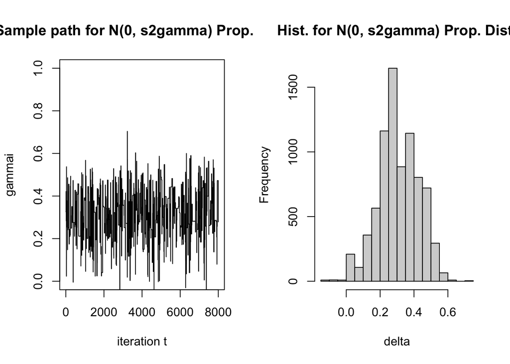

```r
# Evaluate chain diagnostics for the final model
par(mfrow=c(1,2))

# Sample Path: For 1st subject
plot(mhrw.samples[1,], ylim=c(0,1), type="l",
     ylab="gammai", xlab="iteration t",
     main = "Sample path for N(0, s2gamma) Prop. Dist.")

# Histogram
hist(mhrw.samples[1,],breaks=20,xlab="delta",
     main="Hist. for N(0, s2gamma) Prop. Dist.")
```

```r
## End Solution
```